# Tutorial on using sitePath

Chengyang Ji

2019-02-13

## Introduction

The `sitePath` package does hierarchical search for fixation events given multiple sequence alignment and phylogenetic tree. These fixation events can be specific to a phylogenetic lineages or shared by multiple lineages. This is achieved by three major steps:

1. Import tree and sequence alignment
2. Resolve phylogenetic lineages
3. Hierarchical search for lineage-dependent fixation events

## 1. Import tree and sequence alignment

There’re various R packages for parsing phylogenetic tree and multiple sequence alignment files. For now, `sitepath` accepts `phylo` object and `alignment` object. Functions from `ggtree` and `seqinr` are able to handle most file formats.

### 1.1 Parse phylogenetic tree

The S3 phylo class is a common data structure for phylogenetic analysis in R. The CRAN package [ape](https://cran.r-project.org/web/packages/ape/index.html) provides basic parsing function for reading tree files. The Bioconductor package [ggtree](https://bioconductor.org/packages/release/bioc/html/ggtree.html) provides more comprehensive parsing utilities.

```r
library(ape)

tree <- read.tree(system.file("extdata", "ZIKV.newick", package = "sitePath"))
```

Tree should be rooted before further analysis

```r
tree <- root(tree, "ANK57896")
```

### 1.2 Parse and add sequence alignment

Most multiple sequence alignment format can be parsed by [seqinr](https://cran.r-project.org/web/packages/seqinr/index.html). sitePath has a wrapper functin for parsing and adding the sequence alignment

```r
library(sitePath)

alignment_file <- system.file("extdata", "ZIKV.fasta", package = "sitePath")
tree <- addMSA(tree, alignment_file, "fasta")
```

## 2. Resolve phylogenetic lineages

The names in tree and aligment must be matched. The fundamental approach in identifying phylogenetic lineages is trimming tree leaves/tips to expose the major branches. Before finding putative phylogenetic lineages, there involves a few more steps to evalute the impact of threshold on result.

### 2.1 The impact of threshold on resolving lineages

In the current version, the resolving function only takes sequence similarity as one single threshold. The impact of threshold depends on the tree topology hence there is no universal choice. The function `sneakPeak` samples thresholds and calculates the resulting number of paths. *The use of this function can be of great help in choosing the threshold.*

```r
preassessment <- sneakPeek(tree)
```

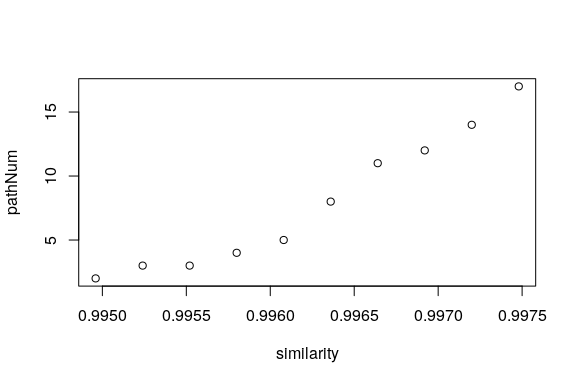

### 2.2 You have to choose a threshold by yourself!

There might be one point where the number of resulting paths has an **unusual drop** and that could be the preferable similarity threshold. For example, here 0.996 is a reasonable choice. You can use the function `sitePath` to get a S3 sitePath class object[^1] for downstream analysis.

```r
paths <- sitePath(tree, 0.996)
paths
```

```
#> 5 paths
```

## 3. Hierarchical search for fixation events

Now you’re ready to find fixation events.

### 3.1 Fixation mutations

The hierarchical search is done by `fixationSites` function. The function outputs a list of mutations with the sequence names involved before and after the fixation.

```r
fixations <- fixationSites(paths)
fixations
```

```
#> N1902H V763M T777M S139N Y2086H M1143V D3398E G894A M2074L R3045C
#> No reference sequence specified. Using alignment numbering
```

The output of `fixtionSites` is an R list. To get the tip names involved in a mutation, you can use index or mutation name to subset the R list

```r
fixations$S139N
```

```
#> $ancestral
#>   [1] "BBC70847" "AUF35022" "ATL14618" "AUF35021" "ANK57896" "AMD61711"
#>   [7] "AQS26698" "APG56458" "APH11550" "APH11586" "APH11535" "APH11544"
#>  [13] "APH11584" "APH11567" "APH11548" "APH11572" "APH11575" "APH11568"
#>  [19] "APH11561" "APH11533" "APH11523" "AWK27349" "APH11545" "APH11554"
#>  [25] "APH11558" "APH11564" "APH11553" "APH11555" "APH11577" "APH11525"
#>  [31] "APH11570" "APH11565" "APH11541" "APH11546" "APH11582" "APH11585"
#>  [37] "APH11563" "APH11504" "APH11587" "APH11499" "APH11498" "APH11503"
#>  [43] "APH11578" "APH11506" "APH11507" "APH11497" "APH11500" "APH11502"
#>  [49] "AVG19202" "APH11539" "APH11534" "APH11592" "APH11594" "APH11518"
#>  [55] "APH11549" "APH11512" "APH11514" "APH11581" "APH11508" "APH11516"
#>  [61] "APH11515" "APH11538" "APH11551" "APH11571" "APH11566" "APH11562"
#>  [67] "APH11595" "APH11528" "APH11560" "APH11543" "APH11529" "APH11573"
#>  [73] "APH11536" "APH11493" "APH11532" "APH11590" "APH11559" "APH11530"
#>  [79] "APH11517" "APH11527" "APH11593" "APH11531" "APH11576" "APH11580"
```

[output cut: 67 more lines]

### 3.2 Visualize the result

Use `plot` to visualize each fixation mutation. You’ll have to specify which mutation to be visualized. Because the `names(fixationSites)` are the mutation names, you can also use one of them as function input

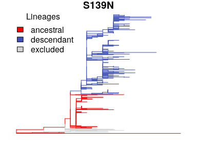

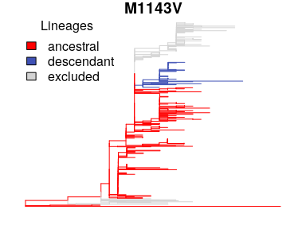

```r
par(mar = c(1,1,1,1))
plot(fixations, "S139N")
plot(fixations, names(fixations)[6])
```

## Additional functions

The above concluded the tutorial. This part is extra and experimental. You may stop here if you wish.

### Just using the trimming function

The function `groupTips` applies the same operation as the function`sitePath` does but it outputs clusters of tree tips instead of paths

```r
grouping <- groupTips(tree, 0.996)
```

### Inspect one site

If you just input the number of the site, the function will plot distribution of amino acid on the tree

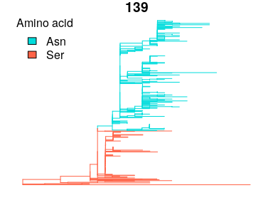

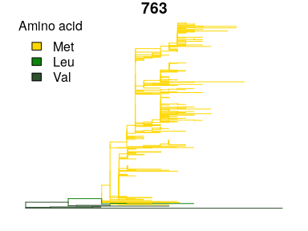

```r
par(mar = c(1,1,1,1))
plot(fixations, 139)
plot(fixations, 763)
```

### SNP sites

An SNP site could potentially undergo fixation event. The `SNPsites` function predicts possible SNP site and the result could be what you’ll expect to be fixation mutation.

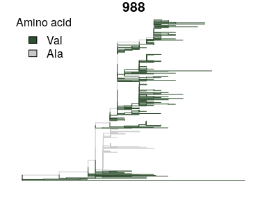

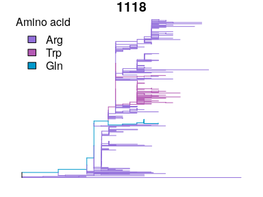

```r
snps <- SNPsites(tree)
par(mar = c(1,1,1,1))
plot(fixations, snps[4])
plot(fixations, snps[5])
```

[^1]: The S3 sitePath object contains the nodes to represent phylogenetic lineages